# QTM 151 - Practice Quiz

**Submit as an HTML file** (see images below)

Step 1: Click the 3 dots in the toolbar for "More Actions"

[figure not shown]

Step 2: Choose "export"

[figure not shown]

Step 3: Select "HTML" from the dropdown window

[figure not shown]

Step 4: Select "Export" in the pop-up window.

[figure not shown]

Upload the .html file as your submission

Print your name below

```python
# Write your answer here

print("Alan Zhao" )
```

```
Alan Zhao
```

This quiz is open book

- You can use the lecture notes
- You will get partial credit for attempting the questions
- To get full credit, the code should work as intended
- You should NOT communicate with other students

Print the following message:

"I will abide by Emory's code of conduct"

```python
# Write your answer here:
print("I will abide by Emory's code of conduct")
```

```
I will abide by Emory's code of conduct
```

Load in any necessary libraries/packages below:

```python
# load in necessary packages/libraries

import pandas as pd
import numpy as np
import matplotlib.pyplot as plt
```

Preliminary check: can you load the data?

In the .zip file you opened, there is a comma-separated values file named  
"HeightWeight-quiz.csv". Using Pandas, create a DataFrame object by reading in this file.

If you get an error, you must figure out what the issue is.

**Note**: This cell is just to test whether you can access the data correctly. If everything works, you can copy and paste the code later in the notebook if you prefer.

```python
# create a DataFrame by loading in the data
# You will need this for questions later.

heightweight = pd.read_csv("data_folder/HeightWeight-quiz.csv")
heightweight
```

|  | Index | Height_Inches | Weight_Pounds |
| --- | --- | --- | --- |
| 0 | 1 | 65.78331 | 112.9925 |
| 1 | 2 | 71.51521 | 136.4873 |
| 2 | 3 | 69.39874 | 153.0269 |
| 3 | 4 | 68.21660 | 142.3354 |
| 4 | 5 | 67.78781 | 144.2971 |
| ... | ... | ... | ... |
| 24995 | 24996 | 69.50215 | 118.0312 |
| 24996 | 24997 | 64.54826 | 120.1932 |
| 24997 | 24998 | 64.69855 | 118.2655 |
| 24998 | 24999 | 67.52918 | 132.2682 |
| 24999 | 25000 | 68.87761 | 124.8742 |

25000 rows × 3 columns

(a) Making changes to a for loop

How would you change the code below, so that it prints out the position in the list of each non-numerical item it encounters?

Implement those changes, and run the code cell

```python
### Make changes to the code below

list_mixed = [1, 2, None, None, 4, 11, "Apple", 2.2, 13, "!!!", None]

list_sum = 0
for index, value in enumerate(list_mixed):

    print(index) # print the index of the current element

    if (type(value) != int) and (type(value) != float):
        print("Warning: Non-numerical element in list!")
        continue

    list_sum = list_sum + value

print(list_sum)
```

```
0
1
2
Warning: Non-numerical element in list!
3
Warning: Non-numerical element in list!
4
5
6
Warning: Non-numerical element in list!
7
8
9
Warning: Non-numerical element in list!
10
Warning: Non-numerical element in list!
33.2
```

(b) Debugging code

Below is a code which attempts to compute the sum $$1 + 2 + 3 + \cdots + (n-1) + n$$ for a positive integer $n$. For this example, we set $n = 10$. In this case, we would expect the output to be: $$ 1 + 2 + 3 + \cdots + 9 + 10 = \frac{10\times 11}{2} = 55$$

but that is not what is printed out when we run the cell below. Find the error in the code, and fix it. Then re-run the cell with $n = 19$, which should print the number $$ \frac{19\times 20}{2} = 190$$

```python
# Find the error and fix it.
# Then run the cell after setting n = 19
n = 19

sum_n = 0
for summands in range(1, n+1):
    sum_n = sum_n + summands
print(sum_n)
```

```
190
```

c) Extracting and sorting subsets of data

In the .zip file you opened, there is a comma-separated values file named  
"HeightWeight-quiz.csv". Using Pandas, create a DataFrame object by reading in this file.

Extract rows 345 through 397 (that is, all the rows 345, 346, 347, ..., 396, 397) of the DataFrame, saving it as another DataFrame. Then sort this subset by Height (lowest to highest), assigning it to a DataFrame called `subset_sorted`

```python
# Write your answer here:

df_new = heightweight.iloc[345:398, :]
df_new

subset_sorted = df_new.sort_values(by = "Height_Inches", ascending = True)
subset_sorted
```

|  | Index | Height_Inches | Weight_Pounds |
| --- | --- | --- | --- |
| 394 | 395 | 63.76881 | 119.3691 |
| 359 | 360 | 64.18633 | 118.4759 |
| 377 | 378 | 64.66007 | 108.6044 |
| 369 | 370 | 65.72927 | 131.8008 |
| 378 | 379 | 65.73721 | 100.6617 |
| 384 | 385 | 66.04157 | 127.8822 |
| 360 | 361 | 66.09074 | 129.5516 |
| 392 | 393 | 66.44873 | 118.9856 |
| 387 | 388 | 66.46042 | 124.5581 |
| 346 | 347 | 66.46536 | 121.5515 |
| 396 | 397 | 66.48966 | 126.6122 |
| 370 | 371 | 66.49627 | 122.8561 |
| 397 | 398 | 66.74224 | 113.5597 |
| 353 | 354 | 67.13983 | 131.5906 |
| 372 | 373 | 67.37579 | 142.6929 |
| 391 | 392 | 67.46867 | 118.7434 |
| 389 | 390 | 67.58249 | 107.5905 |
| 376 | 377 | 67.71342 | 122.6200 |
| 373 | 374 | 67.79709 | 137.4299 |
| 345 | 346 | 67.85566 | 138.8125 |
| 351 | 352 | 67.85651 | 127.7103 |
| 352 | 353 | 68.00435 | 115.6709 |
| 354 | 355 | 68.09931 | 127.5839 |
| 374 | 375 | 68.16070 | 126.0392 |
| 381 | 382 | 68.27367 | 125.6907 |
| 364 | 365 | 68.28613 | 130.0611 |
| 366 | 367 | 68.35315 | 139.3800 |
| 379 | 380 | 68.42441 | 116.1397 |
| 363 | 364 | 68.42721 | 136.1027 |
| 348 | 349 | 68.46886 | 129.4022 |
| 358 | 359 | 68.74304 | 136.9164 |
| 393 | 394 | 68.76185 | 131.8744 |
| 375 | 376 | 68.85782 | 143.5985 |
| 386 | 387 | 68.87697 | 116.3375 |
| 380 | 381 | 68.88946 | 140.5293 |
| 347 | 348 | 68.92071 | 114.2555 |
| 355 | 356 | 68.99077 | 125.7211 |
| 395 | 396 | 69.03663 | 126.1223 |
| 382 | 383 | 69.18045 | 134.3329 |
| 385 | 386 | 69.22880 | 123.1361 |
| 361 | 362 | 69.24418 | 152.0714 |
| 388 | 389 | 69.30444 | 125.7853 |
| 356 | 357 | 69.32618 | 119.9885 |
| 365 | 366 | 69.37684 | 131.7743 |
| 390 | 391 | 69.41816 | 143.0236 |
| 349 | 350 | 69.51930 | 137.5583 |
| 362 | 363 | 69.66512 | 120.8646 |
| 357 | 358 | 70.09286 | 140.8676 |
| 350 | 351 | 70.23956 | 134.4996 |
| 368 | 369 | 70.37159 | 127.6446 |
| 371 | 372 | 70.81339 | 140.2133 |
| 367 | 368 | 72.32489 | 168.2290 |
| 383 | 384 | 72.60996 | 136.4649 |

(d) Filtering a data set

Create two DataFrames containing the following subsets of the data:

- People who weight satisfies $115 \leq \textrm{weight} \leq 140$ (in pounds)
- People who either i) weigh strictly less than 95 pounds **or** ii) are 72 inches or taller (greater than or equal to 72 inches)

```python
# Write your answer here:

df_weight = heightweight.query("Weight_Pounds >= 115 and Weight_Pounds <= 140")
df_weight

df_weightorheight = heightweight.query("Weight_Pounds < 95 or Height_Inches >= 72")
df_weightorheight
```

|  | Index | Height_Inches | Weight_Pounds |
| --- | --- | --- | --- |
| 138 | 139 | 73.90107 | 151.39130 |
| 154 | 155 | 72.44434 | 136.73970 |
| 158 | 159 | 72.01515 | 138.77580 |
| 174 | 175 | 73.83364 | 139.29830 |
| 234 | 235 | 72.74676 | 135.74580 |
| ... | ... | ... | ... |
| 24801 | 24802 | 74.53177 | 148.91040 |
| 24835 | 24836 | 65.17339 | 94.40946 |
| 24883 | 24884 | 73.06241 | 141.50540 |
| 24921 | 24922 | 72.54953 | 134.51430 |
| 24939 | 24940 | 72.35889 | 143.95470 |

505 rows × 3 columns

(e) Random Assignment

We want to divide the dataset into 3 groups randomly: group A, group B, group C

Randomly assign each person in the dataset one of three possible strings: `"A"`, `"B"`, or `"C"`. Add a column/variable to the DataFrame which contains the letter each person is assigned. Give the column/variable the name `"Group"`

**Hint**: Randomly choosing among 3 strings is not much different from randomly choosing among 4 numbers, which is what we did in Lecture 11

```python
# Write your answer here:

random_groups = np.random.choice(['A', 'B', 'C'], size = heightweight.shape[0])
heightweight['Group'] = random_groups
```

(f) Plotting data from one the groups

Create a new DataFrame by extracting all rows corresponding to Group B. Then make a scatter plot of height vs. weight (height on horizontal axis, weight on vertical axis) for the people in this group.

Give appropriate labels to the axes and give your scatter plot a reasonable title.

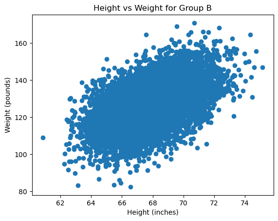

```python
# Write your answer here:

df_B = heightweight[heightweight['Group'] == 'B']

plt.scatter(df_B['Height_Inches'], df_B['Weight_Pounds'])
plt.xlabel("Height (inches)")
plt.ylabel("Weight (pounds)")
plt.title("Height vs Weight for Group B")
plt.show()
```

(g) Convert your notebook to .html

Convert your notebook to .html format. You will be expected to submit your quiz in this format, so now is the time to make sure you can do it. Instructions are at the top of this notebook.

**A small point deduction will be taken off for submissions in the wrong format**